# Chpater 18 Exercises

C組 連昱婷、劉心雨、莊芸綺

2020/5/30

## Question 2

Find all of the cycles of the following congruential generators.  
For each cycle identify which seeds $X_{0}$ lead to that cycle  
(a).$X_{n+1}=9X_{n}+3mod11.$  
(b).$X_{n+1}=8X_{n}+3mod11.$  
(c).$X_{n+1}=8X_{n}+2mod12.$

```r
#a
x <- c()
x[1] <- sample(11, 1)  #隨機從1-11取一整數
print(x[1])
```

```
## [1] 5
```

```r
for(i in c(2:(x[1]*3))){
  x[i] <-(9*x[i-1]+3)%%11  #將20個cycle值輸出
  print(x[i])
}
```

```
## [1] 4
## [1] 6
## [1] 2
## [1] 10
## [1] 5
## [1] 4
## [1] 6
## [1] 2
## [1] 10
## [1] 5
## [1] 4
## [1] 6
## [1] 2
## [1] 10
```

```r
x <- c()
x[1] <- sample(11, 1)  #隨機從1-11取一整數
print(x[1])
```

```
## [1] 11
```

```r
for(i in c(2:20)){
  x[i] <-(8*x[i-1]+3)%%11  #將20個cycle值輸出
  print(x[i])
}
```

```
## [1] 3
## [1] 5
## [1] 10
## [1] 6
## [1] 7
## [1] 4
## [1] 2
## [1] 8
## [1] 1
## [1] 0
## [1] 3
## [1] 5
## [1] 10
## [1] 6
## [1] 7
## [1] 4
## [1] 2
## [1] 8
## [1] 1
```

```r
x <- c()
x[1] <- sample(12, 1)  #隨機從1-12取一整數
print(x[1])
```

```
## [1] 7
```

```r
for(i in c(2:20)){
  x[i] <-(8*x[i-1]+2)%%12  #將20個cycle值輸出
  print(x[i])
}
```

```
## [1] 10
## [1] 10
## [1] 10
## [1] 10
## [1] 10
## [1] 10
## [1] 10
## [1] 10
## [1] 10
## [1] 10
## [1] 10
## [1] 10
## [1] 10
## [1] 10
## [1] 10
## [1] 10
## [1] 10
## [1] 10
## [1] 10
```

## Question 4

Consider the discrete random variable with pmf given by:  
$P(X=1)=0.1$, $P(X=2)=0.3$, $P(X=5)=0.6$.  
a.Plot the cdf for this random variable.  
b.Write a program to simulate a random variable with this distribution, using the built-in function runif(1).  
c.Please plot also the pmf and quantile function in R, in addition to cdf.  
d.Be sure to use open dots and solid dots to indicate discontinuity points that is one-sided continuous.

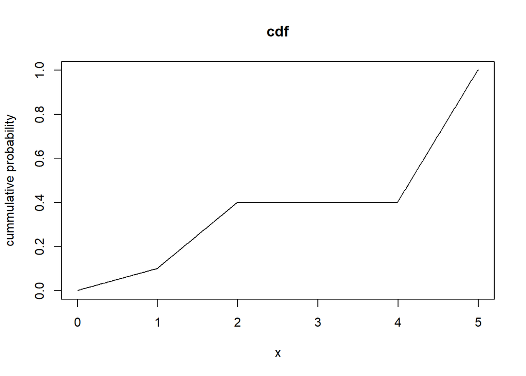

```r
#plot cdf
fx <- function(x) {
  if(x >= 0 && x < 1) {
    res <-  0.1;
  } else if(x >=1 && x < 2) {
    res <- 0.3;
  } else if(x >= 4 && x < 5) {
    res <-  0.6;
  } else {
    res <- 0;
  }
  return(res);
}
fx <- Vectorize(fx)
dx <- 0.01
x <- seq(0, 5, by = dx)
plot(x, cumsum(fx(x) * dx), type = "l", ylab = "cummulative probability", main = "cdf")
```

```r
#simulate a random variable
set.seed(1)
runif(1)
```

```
## [1] 0.2655087
```

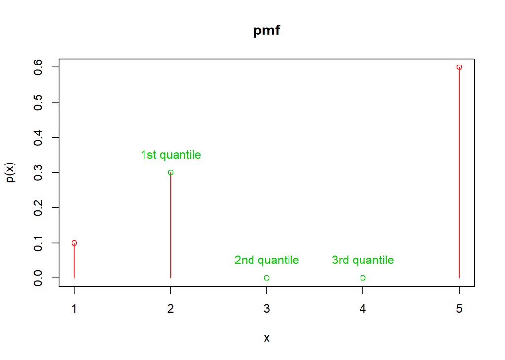

```r
#plot pmf
PP <- c(0.1, 0.3, 0, 0, 0.6)
require(graphics)
plot(PP,type="h",col=2,main="pmf",xlab="x",ylab="p(x)")
points(PP,col=2)
q1 <- ceiling(5*0.25)
points(q1, PP[q1], col=3)
q2 <- ceiling(5*0.5)
points(q2, PP[q2], col=3)
q3 <- ceiling(5*0.75)
points(q3, PP[q3], col=3)
text(q1, PP[q1]+0.05, col=3, "1st quantile")
text(q2, PP[q2]+0.05, col=3, "2nd quantile")
text(q3, PP[q3]+0.05, col=3, "3rd quantile")
```

## Question 6

For X ∼ Poisson(λ) let $F(X)=P(X ≤ x)$ and $p(x) = P(X = x)$.  
Show that the probability function satisfies $p(x+1)=\frac{\lambda}{x+1}p(x).$  
Using this write a function to calculate $p(0), p(1), . . ., p(x) and F(x) = p(0) + p(1) + · · · + p(x).$  
If $X ∈ Z+$ is a random variable and$F(x)$ is a function that returns the cdf $F$ of X,  
then you can simulate $X$ using the following program:  
F.rand <- function () {  
u <- runif(1)  
x <- 0  
while (F(x) < u) {  
x <- x + 1  
}  
return(x)  
}  
In the case of the Poisson distribution, this program can be made more efficient by calculating $F$ just once,  
instead of recalculating it every time you call the function $F(x).$  
By using two new variables, $p.x$ and $F.x$ for $p(x)$ and $F(x)$ respectively,  
modify this program so that instead of using the function $F(x)$ it updates $p.x$ and $F.x$ within the while loop.  
Your program should have the form  
F.rand <- function(lambda) {  
u <- runif(1)  
x <- 0  
p.x <- ?  
F.x <- ?  
while (F.x < u) {  
x <- x + 1  
p.x <- ?  
F.x <- ?  
}  
return(x)  
}  
You should ensure that at the start of the while loop you always have $p.x$ equal to $p(x)$ and $F.x$ equal to $F(x)$.

## Question 18

I.Progamming:  
The Cauchy distribution with parameter α has pdf $f_{x}(x)=\frac{\alpha}{\pi(\alpha^{2}+x^{2})} ,-\infty<x<\infty$  
Write a program to simulate from the Cauchy distribution using the inversion method.  
Now consider using a Cauchy envelope to generate a standard normal random variable using the rejection method.  
Find the values for α and the scaling constant k that minimise the probability of rejection.  
Write an R program to implement the algorithm.

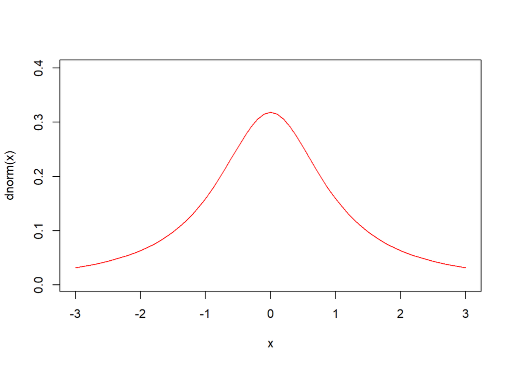

```r
x<-seq(-3,3,by=0.1)
plot(x, dnorm(x),type="n")
lines(x, dcauchy(x),col="red")
```

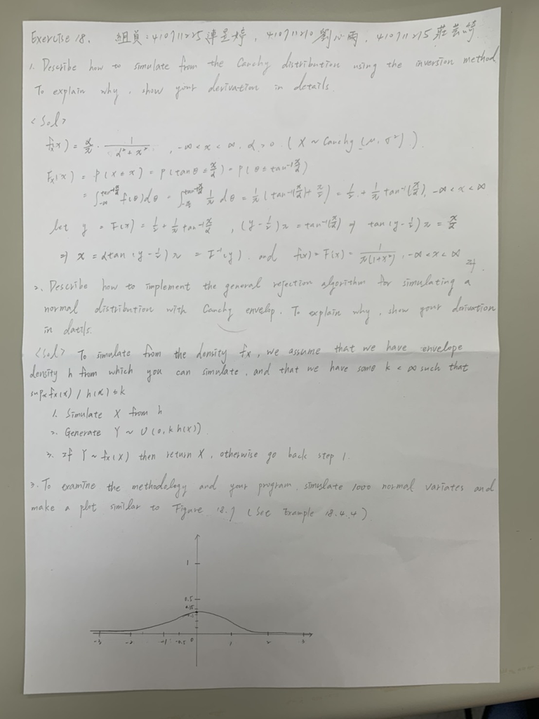

```r
#handwriting
knitr::include_graphics("D:/Numerical Methods/source/chapter18_photo.jpg")
```